# Multiple Linear Regression on King County House Prices Dataset

# Introduction

Multiple Linear Regression (MLR) is a statistical method used to estimate the relationship between a dependent variable and multiple independent variables, assuming a linear relationship between them.

The MLR equation is given by:

$$Y=\beta_0 + \beta_1 X_1 + \beta_2 X_2 +
... + \varepsilon$$

where $\beta_0$ is the intercept, and $\beta_1$ and $\beta_2$ are the coefficients determined by minimizing the sum of the squared differences between observed and predicted values.Once fitted, the model can be used to predict $Y$ for given $X_n$ values.

This study focuses on predicting home prices in King County, Washington using Multiple Linear Regression. The dataset, sourced from Kaggle (www.kaggle.com/datasets/shivachandel/kc-house-data), contains 21,613 records of homes sold between May 2014 and May 2015. We specifically analyzed nine predictors to estimate house prices.

Our investigation leveraged several R packages for data preprocessing, visualization, and modeling. `ggplot2` was used for data visualization, while `tidyr` and `dplyr` helped with data transformation. The `caret` package was used machine learning workflows, and `car`, `lmtest`, and `nlme` were used for regression and linearity testings.

# Data description

```r
housing.df <- read.csv("kc_house_data.csv")
num_rows <- nrow(housing.df)
sum_missingdata <- sum(is.na(housing.df))
cat("Number of Rows: ", num_rows, "   Rows with Missing Data: ", sum_missingdata)
```

```
## Number of Rows:  21613    Rows with Missing Data:  0
```

## Dataset

This dataset contains house sale prices for King County, which includes Seattle.

The dataset consists of house prices from King County an area in the US State of Washington, which also covers Seattle. It includes homes sold between May 2014 and May 2015. There are 10 variables and 21613 observations, of which 9 are features for the target house sales price. From an initial analysis, there were no missing data points.

```r
head(housing.df, 3)
```

|  | price | bedrooms | bathrooms | sqft_living | sqft_lot | floors | waterfront | view | condition | grade |
| --- | --- | --- | --- | --- | --- | --- | --- | --- | --- | --- |
| 1 | 221900 | 3 | 1.00 | 1180 | 5650 | 1 | 0 | 0 | 3 | 7 |
| 2 | 538000 | 3 | 2.25 | 2570 | 7242 | 2 | 0 | 0 | 3 | 7 |
| 3 | 180000 | 2 | 1.00 | 770 | 10000 | 1 | 0 | 0 | 3 | 6 |

## Variables

- price: Price of house sale in currency of USD
- bedrooms: Number of bedrooms
- bathrooms: Number of Bathrooms, where 0.5 represents a bathroom with a toilet but with no shower
- sqft_living: Square footage of the apartments interior living space
- sqft_lot: Square footage of the land space
- floors: Number of floors
- waterfront: An index to indicate if the house was overlooking the waterfront or not. 0 represents no waterfront, 1 represents with waterfront.
- view: An index from 0 to 4 of how good the view of the property was. 0 represents no good view, 4 represents very good view.
- condition: An index from 1 to 5 on the condition of the house. 1 represents poorer condition, and 5 represents superb condition.
- grade: An index from 1 to 13 on quality level of construction and design.

## Outlier Detection

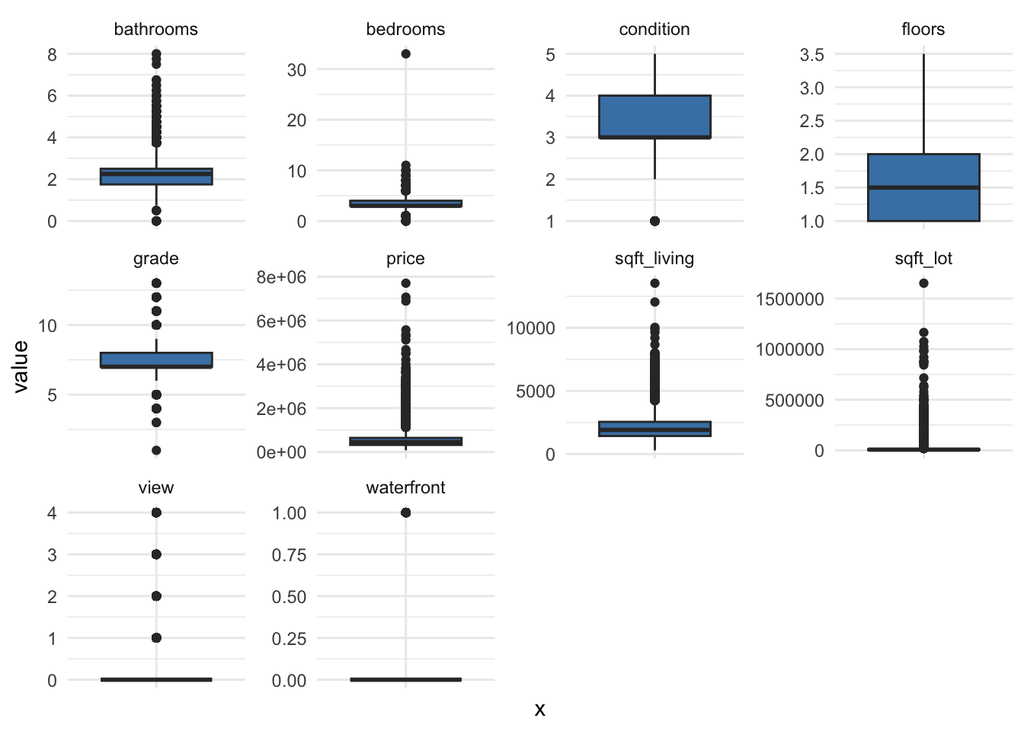

```r
housing_box <- housing.df %>%
  pivot_longer(cols = everything(), names_to = "variable", values_to = "value")
ggplot(housing_box, aes(x = "", y = value)) +
  geom_boxplot(fill = "steelblue") +
  theme_minimal() +
  facet_wrap(~ variable, scales = "free_y") +
  theme(axis.text.x = element_blank(), axis.ticks.x = element_blank())
```

There are evidently outliers in the dataset, and we will primarily concern ourselves with outliers in `price` as that is out dependent variable.

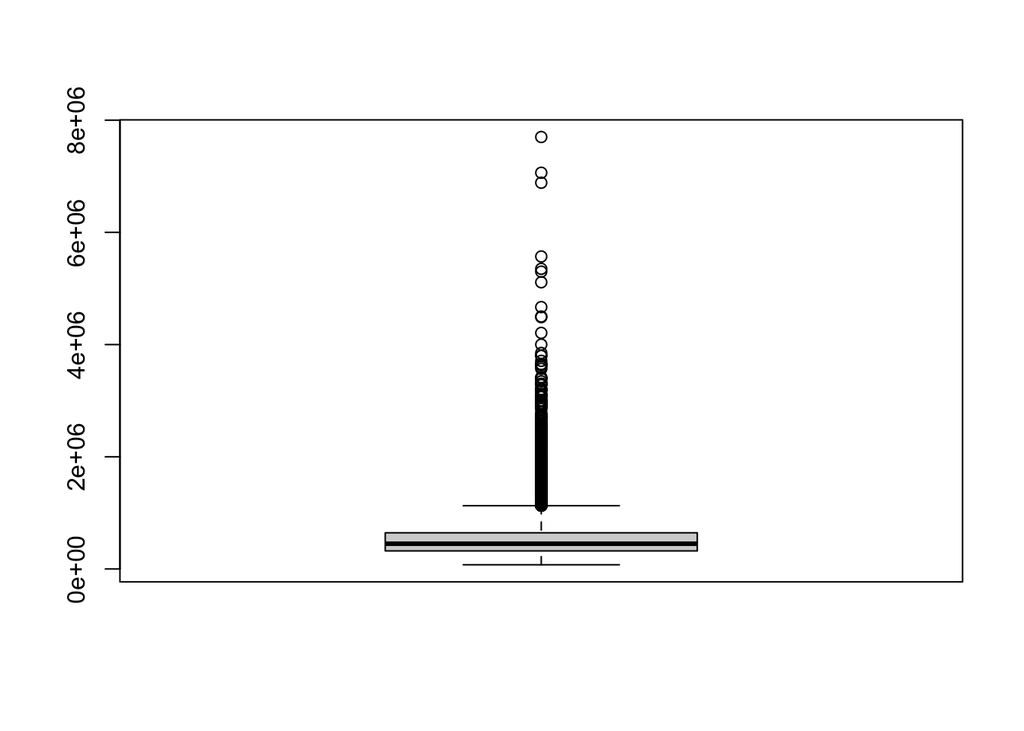

```r
boxplot(housing.df$price)
```

Outlier detection and removal was performed utilizing the IQR method.

```r
q1 <- quantile(housing.df$price, 0.25)
q3 <- quantile(housing.df$price, 0.75)
IQR = IQR(housing.df$price)
outliers <- subset(housing.df, housing.df$price < (q1 - (1.5 * IQR)) | housing.df$price > (q3 + (1.5 * IQR)))
num_outliers <- nrow(outliers)
housing.df <- subset(housing.df, !(rownames(housing.df) %in% rownames(outliers)))
new_ds <- nrow(housing.df)
cat("The dataset with outliers removed now has ", new_ds, "rows.")
```

```
## The dataset with outliers removed now has  20467 rows.
```

The final transformation applied to the dataset involved passing it through a logarithmic function. This transformation was chosen to address skewness in the data and stabilize variance, making it more suitable for MLR modeling in the later stages of this investigation.

```r
housing.df <- log(housing.df+1)
```